# Integrate Download and EDA Functions

davegoblue

6/25/2020

## Background

METAR are hourly weather data collected at airports, including visibility, wind, temperature, dew point, precipitation, clouds, barometric pressure, and other features that may impact safe aviation.

Iowa State University has a great database of archived METAR data, stored in a manner that makes for easy, automated downloads in CSV format.

The files ‘WeatherDownload_202005_v002.Rmd’ and ‘WeatherEDA_202005_v002.Rmd’ contain functions for downloading weather files from the Iowa State server, running EDA, applying a constant format, and saving for further analysis.

The intent of this script is to take the key download and EDA functions, place them in a source file, and then run them as needed to output additional data.

#### *Sourcing Files*

Prior to sourcing functions, here are a few formatting helpers that are included here:

```r
# The functions sourced from the scripts use tidyverse and lubridate frequently
library(tidyverse)
library(lubridate)
```

```r
# Create a regex search string for METAR (the hourly time such as 53Z is pre-pended)
genMET <- ".*?(VRB|\\d{3})(\\d{2})(G\\d{2})?KT(.*?)(\\d{1,2}SM).*?\\s(M?\\d{2})/(M?\\d{2}).*?(A\\d{4}).*?RMK.*?(SLP\\d{3}).*?(T\\d{8})"

# Create the variable names that the above regex parses in to
labsMET <- c("METAR", "WindDir", "WindSpeed", "WindGust", "Dummy", "Visibility",
             "TempC", "DewC", "Altimeter", "SLP", "FahrC"
             )

# Expected columns for the downloaded METAR files
metType <- readr::cols(station=readr::col_character(),
                       valid=readr::col_datetime(),
                       tmpf=readr::col_double(),
                       dwpf=readr::col_double(),
                       relh=readr::col_double(),
                       drct=readr::col_double(),
                       sknt=readr::col_double(),
                       p01i=readr::col_character(),  # needs to handle 'T' for trace
                       alti=readr::col_double(),
                       mslp=readr::col_double(),
                       vsby=readr::col_double(),
                       gust=readr::col_double(),
                       skyc1=readr::col_character(),
                       skyc2=readr::col_character(),
                       skyc3=readr::col_character(),
                       skyc4=readr::col_character(),
                       skyl1=readr::col_double(),
                       skyl2=readr::col_double(),
                       skyl3=readr::col_double(),
                       skyl4=readr::col_double(),
                       wxcodes=readr::col_character(),
                       ice_accretion_1hr=readr::col_character(), # needs to handle 'T' for trace
                       ice_accretion_3hr=readr::col_character(), # needs to handle 'T' for trace
                       ice_accretion_6hr=readr::col_character(), # needs to handle 'T' for trace
                       peak_wind_gust=readr::col_double(),
                       peak_wind_drct=readr::col_double(),
                       peak_wind_time=readr::col_datetime(),
                       feel=readr::col_double(),
                       metar=readr::col_character()
                       )

# The main path for the files
filePath <- "./RInputFiles/ProcessedMETAR/"

# Descriptive names for key variables
varMapper <- c(WindDir="Wind Direction (degrees)",
               predomDir="General Prevailing Wind Direction",
               WindSpeed="Wind Speed (kts)",
               WindSpeed5="Wind Speed (kts), rounded to nearest 5 knots",
               Visibility="Visibility (SM)",
               TempC="Temperature (C)",
               DewC="Dew Point (C)",
               Altimeter="Altimeter (inches Hg)",
               Altimeter10="Altimeter (inches Hg), rounded to nearest 0.1 inHg",
               modSLP="Sea-Level Pressure (hPa)",
               TempF="Temperature (F)",
               DewF="Dew Point (F)",
               TempF5="Temperature (F), rounded to nearest 5 degrees",
               DewF5="Dew Point (F), rounded to nearest 5 degrees",
               cType1="First Cloud Layer Type",
               cLevel1="First Cloud Layer Height (ft)",
               month="Month",
               year="Year",
               wType="Greatest Sky Obscuration",
               day="Day of Month"
               )

# File name to city name mapper
cityNameMapper <- c(katl_2016="Atlanta, GA (2016)",
                    kbos_2016="Boston, MA (2016)",
                    kdca_2016="Washington, DC (2016)",
                    kden_2016="Denver, CO (2016)",
                    kdfw_2016="Dallas, TX (2016)",
                    kdtw_2016="Detroit, MI (2016)",
                    kewr_2016="Newark, NJ (2016)",
                    kgrb_2016="Green Bay, WI (2016)",
                    kgrr_2016="Grand Rapids, MI (2016)",
                    kiah_2016="Houston, TX (2016)",
                    kind_2016="Indianapolis, IN (2016)",
                    klas_2014="Las Vegas, NV (2014)",
                    klas_2015="Las Vegas, NV (2015)",
                    klas_2016="Las Vegas, NV (2016)",
                    klas_2017="Las Vegas, NV (2017)",
                    klas_2018="Las Vegas, NV (2018)",
                    klas_2019="Las Vegas, NV (2019)",
                    klax_2016="Los Angeles, CA (2016)",
                    klnk_2016="Lincoln, NE (2016)",
                    kmia_2016="Miami, FL (2016)",
                    kmke_2016="Milwaukee, WI (2016)",
                    kmsn_2016="Madison, WI (2016)",
                    kmsp_2016="Minneapolis, MN (2016)",
                    kmsy_2014="New Orleans, LA (2014)",
                    kmsy_2015="New Orleans, LA (2015)",
                    kmsy_2016="New Orleans, LA (2016)",
                    kmsy_2017="New Orleans, LA (2017)",
                    kmsy_2018="New Orleans, LA (2018)",
                    kmsy_2019="New Orleans, LA (2019)",
                    kord_2014="Chicago, IL (2014)",
                    kord_2015="Chicago, IL (2015)",
                    kord_2016="Chicago, IL (2016)",
                    kord_2017="Chicago, IL (2017)",
                    kord_2018="Chicago, IL (2018)",
                    kord_2019="Chicago, IL (2019)",
                    kphl_2016="Philadelphia, PA (2016)",
                    kphx_2016="Phoenix, AZ (2016)",
                    ksan_2014="San Diego, CA (2014)",
                    ksan_2015="San Diego, CA (2015)",
                    ksan_2016="San Diego, CA (2016)",
                    ksan_2017="San Diego, CA (2017)",
                    ksan_2018="San Diego, CA (2018)",
                    ksan_2019="San Diego, CA (2019)",
                    ksat_2016="San Antonio, TX (2016)",
                    ksea_2016="Seattle, WA (2016)",
                    ksfo_2016="San Francisco, CA (2016)",
                    ksjc_2016="San Jose, CA (2016)",
                    kstl_2016="Saint Louis, MO (2016)",
                    ktpa_2016="Tampa Bay, FL (2016)",
                    ktvc_2016="Traverse City, MI (2016)"
                    )

# Map of variable to chart name
mapChartVar <- c(p1Inches="1-hr Precip",
                 p36Inches="3-hr or 6-hr Precip",
                 p24Inches="24-hr Precip"
                 )
```

The relevant functions are stored in ‘WeatherDownloadFunctions_v001.R’ and ‘WeatherEDAFunctions_v002.R’. They are now sourced here:

```r
# Functions for downloading and saving a weather file
source("./WeatherDownloadFunctions_v001.R")
source("./WeatherEDAFunctions_v002.R")
```

Lists of files are developed for the following processes in this routine:

- Download raw METAR from Iowa State
- Process downloaded files and convert to common format
- Run EDA and create log file
- Use in integration (for any file not in run EDA, it will just be loaded as-is)

```r
# Define the output file names
metarFileName <- "metar_postEDA_extra_20200627.rds"
precipFileName <- "metar_precipLists_extra_20200627.rds"
cloudFileName <- "metar_modifiedClouds_extra_20200627.rds"

# Define a named list of the stations and years for downloading
downloadFiles <- list(san=c(2014, 2018, 2019),
                      msy=c(2014, 2018, 2019),
                      ord=c(2019),
                      las=c(2014)
                      )

# Define a named list of the stations and years for processing
processFiles <- downloadFiles

# Define a named list of the stations and years for running full EDA with PDF/log outputs
EDAFiles <- downloadFiles

# Define a named list of the stations and years for EDA and integraion
integrateFiles <- list(las=c(2014, 2018, 2019),
                       ord=c(2014, 2018, 2019),
                       msy=c(2014, 2018, 2019),
                       san=c(2014, 2018, 2019),
                       atl=c(2016),
                       bos=c(2016),
                       dca=c(2016),
                       den=c(2016),
                       dfw=c(2016),
                       lax=c(2016),
                       mia=c(2016),
                       phl=c(2016),
                       phx=c(2016),
                       sat=c(2016),
                       sea=c(2016),
                       sfo=c(2016),
                       sjc=c(2016),
                       stl=c(2016),
                       tpa=c(2016)
                       )
```

```r
cat("\nRunning downloads by station for:\n")
```

```
##
## Running downloads by station for:
```

```r
sapply(downloadFiles, FUN=function(x) length(x))
```

```
## san msy ord las
##   3   3   1   1
```

```r
# STEP 1: Download the raw data files from Iowa State
for (station in names(downloadFiles)) {
    for (year in downloadFiles[[station]]) {
        getASOSStationTime(stationID=str_to_upper(station), analysisYears=year, ovrWrite=TRUE)
    }
}
```

```
##
## Data for station SAN from 2013-12-31 to 2015-01-02 will download to ./RInputFiles/metar_ksan_2014.txt
##
##
## Data for station SAN from 2017-12-31 to 2019-01-02 will download to ./RInputFiles/metar_ksan_2018.txt
##
##
## Data for station SAN from 2018-12-31 to 2020-01-02 will download to ./RInputFiles/metar_ksan_2019.txt
##
##
## Data for station MSY from 2013-12-31 to 2015-01-02 will download to ./RInputFiles/metar_kmsy_2014.txt
##
##
## Data for station MSY from 2017-12-31 to 2019-01-02 will download to ./RInputFiles/metar_kmsy_2018.txt
##
##
## Data for station MSY from 2018-12-31 to 2020-01-02 will download to ./RInputFiles/metar_kmsy_2019.txt
##
##
## Data for station ORD from 2018-12-31 to 2020-01-02 will download to ./RInputFiles/metar_kord_2019.txt
##
##
## Data for station LAS from 2013-12-31 to 2015-01-02 will download to ./RInputFiles/metar_klas_2014.txt
##
```

```r
# Exception files with duplicates (potentially clean up to handle these better)
filesNotUnique <- c("metar_ksan_2014", "metar_kmsy_2014", "metar_klas_2014")


cat("\nRunning main EDA process on key files\n")
```

```
##
## Running main EDA process on key files
```

```r
# STEP 2: Process and format the raw data files, and save as .rds
for (station in names(processFiles)) {
    for (year in processFiles[[station]]) {

        coreString <- paste0("metar_k", station, "_", as.character(year))

        cat("\nProcessing Airport:", station, "for year:", year)
        integrateProcessingMETAR(paste0("./RInputFiles/", coreString, ".txt"),
                                 startDay=paste0(as.character(year-1), "-12-31"),
                                 endDay=paste0(as.character(year+1), "-01-01"),
                                 genMET=genMET,
                                 labsMET=labsMET,
                                 saveLoc=paste0("./RInputFiles/ProcessedMETAR/", coreString, ".rds"),
                                 ovrWrite=TRUE,
                                 colTypes=metType,
                                 logFile=paste0("./RInputFiles/ProcessedMETAR/", coreString, ".log"),
                                 useNAforIncomplete=TRUE,
                                 showSLPGraph=FALSE,
                                 errNonUnique=(!(coreString %in% filesNotUnique))
                                 )
        cat("\nFinished Processing Airport:", station, "in year:", year,"\n")

    }
}
```

```
##
## Processing Airport: san for year: 2014
## Most common 10 times for file: ./RInputFiles/metar_ksan_2014.txt
## .
##  51Z  58Z  06Z  43Z  30Z  46Z  31Z  41Z  42Z  01Z
## 8799   60   53   48   47   47   46   43   42   40
##
## The most common Zulu time for ./RInputFiles/metar_ksan_2014.txt is 51Z
## Frequency is 83.4 % ( 8799 of 10548 )
##
## *** OBSERVATIONS EXPECTED BUT NOT RECORDED: 25 ***
##
##
## *** OBSERVATIONS RECORDED BUT NOT EXPECTED: 0 ***
##
## *** Are the extracted records unique? ***
##  FALSE
##
##
## *** Tentative Summary of Element Parsing ***
## .
## FALSE  TRUE
##     3  8780
```

```
##
##  *** Number of NA values ***
##      METAR    WindDir  WindSpeed   WindGust      Dummy Visibility      TempC
##          3          3          3       8783          3          3          3
##       DewC  Altimeter        SLP      FahrC      dtime  origMETAR      TempF
##          3          3          3          3          0          0          3
##       DewF
##          3
##
## Visibilities after correcting for fractions:
## 0.0625  0.125   0.25    0.5   0.75      1   1.25    1.5   1.75      2    2.5
##      1      6     15     22      9     17      7      9      5     26     21
##      3      4      5      6      7      8      9     10   <NA>
##     31     46    109    188    276    345    521   7126      3
##
##
## Counts of wind gusts extracted:
##   14   15   16   17   18   19   20   21   22   23   24   25   26   27   28   30
##   12   18   13   21   23   17   19    5    9    7    7    3    1    1    2    4
##   32   33   35   39 <NA>
##    1    1    1    2 8616
##
##
## There are 1 issues with clouds data (see logfile):
##
## # A tibble: 7 x 2
##   wType     n
##   <fct> <int>
## 1 VV       31
## 2 OVC    1493
## 3 BKN    2750
## 4 SCT    1728
## 5 FEW    1631
## 6 CLR    1147
## 7 Error     3
##
## All Zulu times in the METAR are consistent with the datetime variable
##
## Over-writing existing file: ./RInputFiles/ProcessedMETAR/metar_ksan_2014.rds
##
```

[output cut: 10 more lines]

```
## Frequency is 86.2 % ( 8792 of 10197 )
##
## *** OBSERVATIONS EXPECTED BUT NOT RECORDED: 16 ***
##
##
## *** OBSERVATIONS RECORDED BUT NOT EXPECTED: 0 ***
##
## *** Are the extracted records unique? ***
##  TRUE
##
##
## *** Tentative Summary of Element Parsing ***
## .
## FALSE  TRUE
##     6  8786
```

```
##
##  *** Number of NA values ***
##      METAR    WindDir  WindSpeed   WindGust      Dummy Visibility      TempC
##          6          6          6       8792          6          6          6
##       DewC  Altimeter        SLP      FahrC      dtime  origMETAR      TempF
##          6          6          6          6          0          0          6
##       DewF
##          6
##
## Visibilities after correcting for fractions:
## 0.0625  0.125   0.25    0.5   0.75      1   1.25    1.5   1.75      2    2.5
##      3      7     25     16      7      8      2      8      6     23     23
##      3      4      5      6      7      8      9     10   <NA>
##     66     95    112    213    248    253    387   7284      6
##
##
## Counts of wind gusts extracted:
##   14   15   16   17   18   19   20   21   22   23   24   25   26   27   28   29
##    2   13    7   12   11   15   15   18    7    6    9    2    2    2    1    1
##   31 <NA>
##    1 8668
##
##
## wType as created from clouds data is consistent
## # A tibble: 7 x 2
##   wType     n
##   <fct> <int>
## 1 VV       40
## 2 OVC    1883
## 3 BKN    2681
## 4 SCT    1330
## 5 FEW    1994
## 6 CLR     858
## 7 Error     6
##
## All Zulu times in the METAR are consistent with the datetime variable
##
## Over-writing existing file: ./RInputFiles/ProcessedMETAR/metar_ksan_2018.rds
##
##
```

[output cut: 9 more lines]

```
## Frequency is 86.1 % ( 8803 of 10226 )
##
## *** OBSERVATIONS EXPECTED BUT NOT RECORDED: 5 ***
##
##
## *** OBSERVATIONS RECORDED BUT NOT EXPECTED: 0 ***
##
## *** Are the extracted records unique? ***
##  TRUE
##
##
## *** Tentative Summary of Element Parsing ***
## .
## FALSE  TRUE
##     9  8794
```

```
##
##  *** Number of NA values ***
##      METAR    WindDir  WindSpeed   WindGust      Dummy Visibility      TempC
##          9          9          9       8803          9          9          9
##       DewC  Altimeter        SLP      FahrC      dtime  origMETAR      TempF
##          9          9          9          9          0          0          9
##       DewF
##          9
##
## Visibilities after correcting for fractions:
## 0.25  0.5 0.75    1 1.25  1.5 1.75    2  2.5    3    4    5    6    7    8    9
##    5    6    6    7    3   17    8   24   15   66   65   86  158  227  252  384
##   10 <NA>
## 7465    9
##
##
## Counts of wind gusts extracted:
##   14   15   16   17   18   19   20   21   22   23   24   25   26   27   28   29
##    8   32   37   56   59   46   34   20   14   11    3    2    2    2    3    1
##   30   31   32   33   34   35   36   40 <NA>
##    1    2    3    2    2    1    1    1 8460
##
##
## There are 2 issues with clouds data (see logfile):
##
## # A tibble: 7 x 2
##   wType     n
##   <fct> <int>
## 1 VV        5
## 2 OVC    2094
## 3 BKN    2715
## 4 SCT    1210
## 5 FEW    1924
## 6 CLR     844
## 7 Error    11
##
## All Zulu times in the METAR are consistent with the datetime variable
##
## Over-writing existing file: ./RInputFiles/ProcessedMETAR/metar_ksan_2019.rds
##
```

[output cut: 10 more lines]

```
## Frequency is 82.2 % ( 8782 of 10689 )
##
## *** OBSERVATIONS EXPECTED BUT NOT RECORDED: 27 ***
##
##
## *** OBSERVATIONS RECORDED BUT NOT EXPECTED: 0 ***
##
## *** Are the extracted records unique? ***
##  FALSE
##
##
## *** Tentative Summary of Element Parsing ***
## .
## FALSE  TRUE
##    20  8761
```

```
##
##  *** Number of NA values ***
##      METAR    WindDir  WindSpeed   WindGust      Dummy Visibility      TempC
##         20         20         20       8781         20         20         20
##       DewC  Altimeter        SLP      FahrC      dtime  origMETAR      TempF
##         20         20         20         20          0          0         20
##       DewF
##         20
##
## Visibilities after correcting for fractions:
## 0.0625  0.125   0.25    0.5   0.75      1   1.25    1.5   1.75      2    2.5
##      9     30     33     41     13     17     13     20      6     36     20
##      3      4      5      6      7      8      9     10   <NA>
##     70     87    127    167    292    323    418   7039     20
##
##
## Counts of wind gusts extracted:
##   14   15   16   17   18   19   20   21   22   23   24   25   26   27   28   29
##    7   14   21   25   41   66   63   68   81   61   41   46   28   23   22   10
##   30   31   32   33   34   35   36   37 <NA>
##    3    8    2    1    3    1    1    1 8144
##
##
## wType as created from clouds data is consistent
## # A tibble: 7 x 2
##   wType     n
##   <fct> <int>
## 1 VV       77
## 2 OVC    1706
## 3 BKN    2939
## 4 SCT    1390
## 5 FEW    1670
## 6 CLR     979
## 7 Error    20
##
## All Zulu times in the METAR are consistent with the datetime variable
##
## Over-writing existing file: ./RInputFiles/ProcessedMETAR/metar_kmsy_2014.rds
##
##
```

[output cut: 9 more lines]

```
## Frequency is 81.6 % ( 8784 of 10771 )
##
## *** OBSERVATIONS EXPECTED BUT NOT RECORDED: 24 ***
##
##
## *** OBSERVATIONS RECORDED BUT NOT EXPECTED: 0 ***
##
## *** Are the extracted records unique? ***
##  TRUE
##
##
## *** Tentative Summary of Element Parsing ***
## .
## FALSE  TRUE
##     7  8777
```

```
##
##  *** Number of NA values ***
##      METAR    WindDir  WindSpeed   WindGust      Dummy Visibility      TempC
##          7          7          7       8784          7          7          7
##       DewC  Altimeter        SLP      FahrC      dtime  origMETAR      TempF
##          7          7          7          7          0          0          7
##       DewF
##          7
##
## Visibilities after correcting for fractions:
## 0.125  0.25   0.5  0.75     1  1.25   1.5  1.75     2   2.5     3     4     5
##    17    24    23    21    20     6    11     8    60    20    80    75   115
##     6     7     8     9    10  <NA>
##   212   309   407   474  6895     7
##
##
## Counts of wind gusts extracted:
##   14   15   16   17   18   19   20   21   22   23   24   25   26   27   28   29
##   10   36   61   74   87  100   92   74   73   50   37   21   17   14   16    6
##   30   31   32   33   34   35   36   41 <NA>
##    3    2    3    3    2    1    1    1 8000
##
##
## wType as created from clouds data is consistent
## # A tibble: 7 x 2
##   wType     n
##   <fct> <int>
## 1 VV       52
## 2 OVC    1729
## 3 BKN    3049
## 4 SCT    1485
## 5 FEW    1722
## 6 CLR     740
## 7 Error     7
##
## All Zulu times in the METAR are consistent with the datetime variable
##
## Over-writing existing file: ./RInputFiles/ProcessedMETAR/metar_kmsy_2018.rds
##
##
```

[output cut: 9 more lines]

```
## Frequency is 82.9 % ( 8797 of 10611 )
##
## *** OBSERVATIONS EXPECTED BUT NOT RECORDED: 11 ***
##
##
## *** OBSERVATIONS RECORDED BUT NOT EXPECTED: 0 ***
##
## *** Are the extracted records unique? ***
##  TRUE
##
##
## *** Tentative Summary of Element Parsing ***
## .
## FALSE  TRUE
##     8  8789
```

```
##
##  *** Number of NA values ***
##      METAR    WindDir  WindSpeed   WindGust      Dummy Visibility      TempC
##          8          8          8       8797          8          8          8
##       DewC  Altimeter        SLP      FahrC      dtime  origMETAR      TempF
##          8          8          8          8          0          0          8
##       DewF
##          8
##
## Visibilities after correcting for fractions:
## 0.0625  0.125   0.25    0.5   0.75      1   1.25    1.5   1.75      2    2.5
##      6     34     63     40     22     34      8     22     14     45     33
##      3      4      5      6      7      8      9     10   <NA>
##     82     83    121    169    233    274    341   7165      8
##
##
## Counts of wind gusts extracted:
##   14   15   16   17   18   19   20   21   22   23   24   25   26   27   28   29
##   10   40   58  100   94  108  109   76   75   66   36   34   27   20   14   14
##   30   31   32   33   34   35   36   37   38   41   51 <NA>
##    6    6    8    8    3    3    1    1    2    2    1 7875
##
##
## wType as created from clouds data is consistent
## # A tibble: 7 x 2
##   wType     n
##   <fct> <int>
## 1 VV      100
## 2 OVC    2145
## 3 BKN    2861
## 4 SCT    1222
## 5 FEW    1580
## 6 CLR     881
## 7 Error     8
##
## All Zulu times in the METAR are consistent with the datetime variable
##
## Over-writing existing file: ./RInputFiles/ProcessedMETAR/metar_kmsy_2019.rds
##
##
```

[output cut: 9 more lines]

```
## Frequency is 80.3 % ( 8798 of 10954 )
##
## *** OBSERVATIONS EXPECTED BUT NOT RECORDED: 10 ***
##
##
## *** OBSERVATIONS RECORDED BUT NOT EXPECTED: 0 ***
##
## *** Are the extracted records unique? ***
##  TRUE
##
##
## *** Tentative Summary of Element Parsing ***
## .
## FALSE  TRUE
##     7  8791
```

```
##
##  *** Number of NA values ***
##      METAR    WindDir  WindSpeed   WindGust      Dummy Visibility      TempC
##          7          7          7       8798          7          7          7
##       DewC  Altimeter        SLP      FahrC      dtime  origMETAR      TempF
##          7          7          7          7          0          0          7
##       DewF
##          7
##
## Visibilities after correcting for fractions:
## 0.125  0.25   0.5  0.75     1  1.25   1.5  1.75     2   2.5     3     4     5
##     6    21    29    45    36    18    30    34    60    65   111   147   196
##     6     7     8     9    10  <NA>
##   192   231   238   239  7093     7
##
##
## Counts of wind gusts extracted:
##   12   13   14   15   16   17   18   19   20   21   22   23   24   25   26   27
##    1    1    8   23   57  104  142  166  187  168  148  141  109  103  101   78
##   28   29   30   31   32   33   34   35   36   37   38   39   40   41   42   43
##   60   61   37   24   30   18   12   18   10    8    8    2    9    4    2    5
##   44   45   46   47   48 <NA>
##    2    1    3    1    1 6945
##
##
## wType as created from clouds data is consistent
## # A tibble: 7 x 2
##   wType     n
##   <fct> <int>
## 1 VV       57
## 2 OVC    3713
## 3 BKN    2151
## 4 SCT     929
## 5 FEW    1300
## 6 CLR     641
## 7 Error     7
##
## All Zulu times in the METAR are consistent with the datetime variable
##
## Over-writing existing file: ./RInputFiles/ProcessedMETAR/metar_kord_2019.rds
```

[output cut: 11 more lines]

```
## Frequency is 97.1 % ( 8788 of 9050 )
##
## *** OBSERVATIONS EXPECTED BUT NOT RECORDED: 21 ***
##
##
## *** OBSERVATIONS RECORDED BUT NOT EXPECTED: 0 ***
##
## *** Are the extracted records unique? ***
##  FALSE
##
##
## *** Tentative Summary of Element Parsing ***
## .
## FALSE  TRUE
##    51  8736
```

```
##
##  *** Number of NA values ***
##      METAR    WindDir  WindSpeed   WindGust      Dummy Visibility      TempC
##         51         51         51       8787         51         51         51
##       DewC  Altimeter        SLP      FahrC      dtime  origMETAR      TempF
##         51         51         51         51          0          0         51
##       DewF
##         51
##
## Visibilities after correcting for fractions:
## 0.25  0.5 0.75 1.25  1.5 1.75    2  2.5    4    5    6    7    8    9   10 <NA>
##    1    2    2    1    2    1    1    3    3    5    6   18   25   36 8630   51
##
##
## Counts of wind gusts extracted:
##   14   15   16   17   18   19   20   21   22   23   24   25   26   27   28   29
##   20   27   54   55   60   82  100  113  123  119   92   79   79   72   49   44
##   30   31   32   33   34   35   36   37   38   39   40   41   42   43   44 <NA>
##   30   28   31   23   12   12    8    7    4    7    4    3    1    1    1 7447
##
##
## There are 1 issues with clouds data (see logfile):
##
## # A tibble: 7 x 2
##   wType     n
##   <fct> <int>
## 1 VV        3
## 2 OVC     636
## 3 BKN    2156
## 4 SCT    1384
## 5 FEW    1899
## 6 CLR    2658
## 7 Error    51
##
## All Zulu times in the METAR are consistent with the datetime variable
##
## Creating file: ./RInputFiles/ProcessedMETAR/metar_klas_2014.rds
##
##
## Finished Processing Airport: las in year: 2014
```

Only the components of the EDA that are essential to checking the data and creating an output file for analysis are included.

The EDA is split such that the files in EDAFiles have a full EDA process run while the remaining files in integratedFiles are merely loaded with the appropriate name:

```r
# STEP 3a: Create the list of files to be run, process EDA, and output log files
edaNames <- character(0)
for (station in names(EDAFiles)) {
    for (year in EDAFiles[[station]]) {
        edaNames <- c(edaNames, paste0("k", station, "_", as.character(year)))
    }
}

cat("\nEDA process will be run for all of:\n\n", paste0(edaNames, collapse="\n"), "\n", sep="")
```

```
##
## EDA process will be run for all of:
##
## ksan_2014
## ksan_2018
## ksan_2019
## kmsy_2014
## kmsy_2018
## kmsy_2019
## kord_2019
## klas_2014
```

```r
for (fName in edaNames) {
    assign(fName, logAndPDFCombinedEDA(fName))
}
```

```
##
## RDS Name: metar_ksan_2014.rds
## Log Name: metar_ksan_2014_EDA.log
## PDF Name: metar_ksan_2014_EDA.pdf
## Will use San Diego, CA (2014) as the description for metar_ksan_2014.rds
##
##
## EDA PDF file is available at: ./RInputFiles/ProcessedMETAR/metar_ksan_2014_EDA.pdf
##
## EDA log file is available at: ./RInputFiles/ProcessedMETAR/metar_ksan_2014_EDA.log
```

```
##
## RDS Name: metar_ksan_2018.rds
## Log Name: metar_ksan_2018_EDA.log
## PDF Name: metar_ksan_2018_EDA.pdf
## Will use San Diego, CA (2018) as the description for metar_ksan_2018.rds
##
##
## EDA PDF file is available at: ./RInputFiles/ProcessedMETAR/metar_ksan_2018_EDA.pdf
##
## EDA log file is available at: ./RInputFiles/ProcessedMETAR/metar_ksan_2018_EDA.log
```

```
##
## RDS Name: metar_ksan_2019.rds
## Log Name: metar_ksan_2019_EDA.log
## PDF Name: metar_ksan_2019_EDA.pdf
## Will use San Diego, CA (2019) as the description for metar_ksan_2019.rds
##
##
## EDA PDF file is available at: ./RInputFiles/ProcessedMETAR/metar_ksan_2019_EDA.pdf
##
## EDA log file is available at: ./RInputFiles/ProcessedMETAR/metar_ksan_2019_EDA.log
```

```
##
## RDS Name: metar_kmsy_2014.rds
## Log Name: metar_kmsy_2014_EDA.log
## PDF Name: metar_kmsy_2014_EDA.pdf
## Will use New Orleans, LA (2014) as the description for metar_kmsy_2014.rds
##
##
## EDA PDF file is available at: ./RInputFiles/ProcessedMETAR/metar_kmsy_2014_EDA.pdf
##
## EDA log file is available at: ./RInputFiles/ProcessedMETAR/metar_kmsy_2014_EDA.log
```

```
##
## RDS Name: metar_kmsy_2018.rds
## Log Name: metar_kmsy_2018_EDA.log
## PDF Name: metar_kmsy_2018_EDA.pdf
## Will use New Orleans, LA (2018) as the description for metar_kmsy_2018.rds
##
##
## EDA PDF file is available at: ./RInputFiles/ProcessedMETAR/metar_kmsy_2018_EDA.pdf
##
## EDA log file is available at: ./RInputFiles/ProcessedMETAR/metar_kmsy_2018_EDA.log
```

```
##
## RDS Name: metar_kmsy_2019.rds
## Log Name: metar_kmsy_2019_EDA.log
## PDF Name: metar_kmsy_2019_EDA.pdf
## Will use New Orleans, LA (2019) as the description for metar_kmsy_2019.rds
##
##
## EDA PDF file is available at: ./RInputFiles/ProcessedMETAR/metar_kmsy_2019_EDA.pdf
##
## EDA log file is available at: ./RInputFiles/ProcessedMETAR/metar_kmsy_2019_EDA.log
```

```
##
## RDS Name: metar_kord_2019.rds
## Log Name: metar_kord_2019_EDA.log
## PDF Name: metar_kord_2019_EDA.pdf
## Will use Chicago, IL (2019) as the description for metar_kord_2019.rds
##
##
## EDA PDF file is available at: ./RInputFiles/ProcessedMETAR/metar_kord_2019_EDA.pdf
##
## EDA log file is available at: ./RInputFiles/ProcessedMETAR/metar_kord_2019_EDA.log
```

```
##
## RDS Name: metar_klas_2014.rds
## Log Name: metar_klas_2014_EDA.log
## PDF Name: metar_klas_2014_EDA.pdf
## Will use Las Vegas, NV (2014) as the description for metar_klas_2014.rds
##
##
## EDA PDF file is available at: ./RInputFiles/ProcessedMETAR/metar_klas_2014_EDA.pdf
##
## EDA log file is available at: ./RInputFiles/ProcessedMETAR/metar_klas_2014_EDA.log
```

```r
# STEP 3b: Simply load all other files in integrateFiles
loadOnlyNames <- character(0)
for (station in names(integrateFiles)) {
    for (year in integrateFiles[[station]]) {
        loadOnlyNames <- c(loadOnlyNames, paste0("k", station, "_", as.character(year)))
    }
}

# Restrict to loading only the files not already loaded through the EDA process
loadOnlyNames <- setdiff(loadOnlyNames, edaNames)

cat("\nLoad as-is without EDA will be run for all of:\n\n",
    paste0(loadOnlyNames, collapse="\n"),
    "\n",
    sep=""
    )
```

```
##
## Load as-is without EDA will be run for all of:
##
## klas_2018
## klas_2019
## kord_2014
## kord_2018
## katl_2016
## kbos_2016
## kdca_2016
## kden_2016
## kdfw_2016
## klax_2016
## kmia_2016
## kphl_2016
## kphx_2016
## ksat_2016
## ksea_2016
## ksfo_2016
## ksjc_2016
## kstl_2016
## ktpa_2016
```

```r
for (fName in loadOnlyNames) {
    assign(fName, readRDS(paste0(filePath, "metar_", fName, ".rds")))
}


# STEP 3c: Ensure that integrateNames includes everything in edaNames and loadOnlyNames
integrateNames <- union(edaNames, loadOnlyNames)
```

```r
cat("\nRunning the rain data\n")
```

```
##
## Running the rain data
```

```r
# NEED TO FIX for Chicago 2014 rainfall - time recorded as 013 should be 0013
# Should fix function fnPrecip1-fnPrecip6 to handle this better
if (exists("kord_2014")) {
    kord_2014 <- kord_2014 %>%
        mutate(origMETAR=str_replace(origMETAR, pattern="RAB013 ", replacement="RAB0013 "))
}

# Run for rain, with logs and pdf sent to files
rain_List <- wrapPrecipTimes(integrateNames,
                             pType="(?<!FZ)RA",
                             pExt="_RA",
                             pTypeName="rain",
                             writeLogFile="rain_extra0625_IntervalTimes.log",
                             writeLogPDF="rain_extra0625_IntervalTimes.pdf",
                             writeLogPath=filePath,
                             appendWriteFile=FALSE
                             )
```

```
##
## Precipitation times log file is available at: ./RInputFiles/ProcessedMETAR/rain_extra0625_IntervalTimes.log
```

```
##
## Summary of mismatch lengths after processing - see log file if needed
##              [,1]
## ksan_2014_RA    0
## ksan_2018_RA    0
## ksan_2019_RA    0
## kmsy_2014_RA    0
## kmsy_2018_RA    0
## kmsy_2019_RA    0
## kord_2019_RA    0
## klas_2014_RA    0
## klas_2018_RA    0
## klas_2019_RA    0
## kord_2014_RA    0
## kord_2018_RA    0
## katl_2016_RA    0
## kbos_2016_RA    0
## kdca_2016_RA    0
## kden_2016_RA    0
## kdfw_2016_RA    0
## klax_2016_RA    0
## kmia_2016_RA    0
## kphl_2016_RA    0
## kphx_2016_RA    0
## ksat_2016_RA    0
## ksea_2016_RA    0
## ksfo_2016_RA    0
## ksjc_2016_RA    0
## kstl_2016_RA    0
## ktpa_2016_RA    0
##
## Precipitation times PDF file is available at: ./RInputFiles/ProcessedMETAR/rain_extra0625_IntervalTimes.pdf
##
## Will use minTime: 2016-01-01 and maxTime: 2016-12-31
```

[output not shown]

```r
cat("\nRunning the snow data\n")
```

```
##
## Running the snow data
```

```r
# Run for snow, with logs and pdf sent to files
snow_List <- wrapPrecipTimes(integrateNames,
                             pType="(?<!BL)SN",
                             pExt="_SN",
                             pTypeName="snow",
                             writeLogFile="snow_extra0625_IntervalTimes.log",
                             writeLogPDF="snow_extra0625_IntervalTimes.pdf",
                             writeLogPath=filePath,
                             appendWriteFile=FALSE
                             )
```

```
##
## Precipitation times log file is available at: ./RInputFiles/ProcessedMETAR/snow_extra0625_IntervalTimes.log
##
## Summary of mismatch lengths after processing - see log file if needed
##              [,1]
## ksan_2014_SN    0
## ksan_2018_SN    0
## ksan_2019_SN    0
## kmsy_2014_SN    0
## kmsy_2018_SN    0
## kmsy_2019_SN    0
## kord_2019_SN    0
## klas_2014_SN    0
## klas_2018_SN    0
## klas_2019_SN    0
## kord_2014_SN    0
## kord_2018_SN    0
## katl_2016_SN    0
## kbos_2016_SN    0
## kdca_2016_SN    0
## kden_2016_SN    0
## kdfw_2016_SN    0
## klax_2016_SN    0
## kmia_2016_SN    0
## kphl_2016_SN    0
## kphx_2016_SN    0
## ksat_2016_SN    0
## ksea_2016_SN    0
## ksfo_2016_SN    0
## ksjc_2016_SN    0
## kstl_2016_SN    0
## ktpa_2016_SN    0
##
## Precipitation times PDF file is available at: ./RInputFiles/ProcessedMETAR/snow_extra0625_IntervalTimes.pdf
##
## Will use minTime: 2016-01-01 and maxTime: 2016-12-31
```

[output not shown]

```r
cat("\nRunning the thunder data\n")
```

```
##
## Running the thunder data
```

```r
# NEED TO FIX for Saint Louis 2016 thunder - time recorded as TSE57 should be TSE0757
# Should fix function fnPrecip1-fnPrecip6 to handle this better
if (exists("kstl_2016")) {
    kstl_2016 <- kstl_2016 %>%
        mutate(origMETAR=str_replace(origMETAR, pattern="TSE57 ", replacement="TSE0757 "))
}

# Run for thunder, with logs and pdf sent to files
thunder_List <- wrapPrecipTimes(integrateNames,
                                pType="(?<!VC)TS",
                                pExt="_TS",
                                pTypeName="thunder",
                                writeLogFile="thunder_extra0625_IntervalTimes.log",
                                writeLogPDF="thunder_extra0625_IntervalTimes.pdf",
                                writeLogPath=filePath,
                                appendWriteFile=FALSE
                                )
```

```
##
## Precipitation times log file is available at: ./RInputFiles/ProcessedMETAR/thunder_extra0625_IntervalTimes.log
##
## Summary of mismatch lengths after processing - see log file if needed
##              [,1]
## ksan_2014_TS    0
## ksan_2018_TS    0
## ksan_2019_TS    0
## kmsy_2014_TS    0
## kmsy_2018_TS    0
## kmsy_2019_TS    0
## kord_2019_TS    0
## klas_2014_TS    0
## klas_2018_TS    0
## klas_2019_TS    0
## kord_2014_TS    0
## kord_2018_TS    0
## katl_2016_TS    0
## kbos_2016_TS    0
## kdca_2016_TS    0
## kden_2016_TS    0
## kdfw_2016_TS    0
## klax_2016_TS    0
## kmia_2016_TS    0
## kphl_2016_TS    0
## kphx_2016_TS    0
## ksat_2016_TS    0
## ksea_2016_TS    0
## ksfo_2016_TS    0
## ksjc_2016_TS    0
## kstl_2016_TS    0
## ktpa_2016_TS    0
##
## Precipitation times PDF file is available at: ./RInputFiles/ProcessedMETAR/thunder_extra0625_IntervalTimes.pdf
##
## Will use minTime: 2016-01-01 and maxTime: 2016-12-31
```

[output not shown]

Daily high-low temperatures and precipitation summaries are extracted, an integrated file is produced, and a predominant wind direction is added:

```r
# Get the high-low data for every file in integrateNames
# Get the daily precipitation data for every file in integrateNames
# Combine the relevant data files
# Create the predominant wind direction
all_hilo <- extractDailyHighLow(integrateNames)
all_pin <- extractDailyPrecipitation(integrateNames)
```

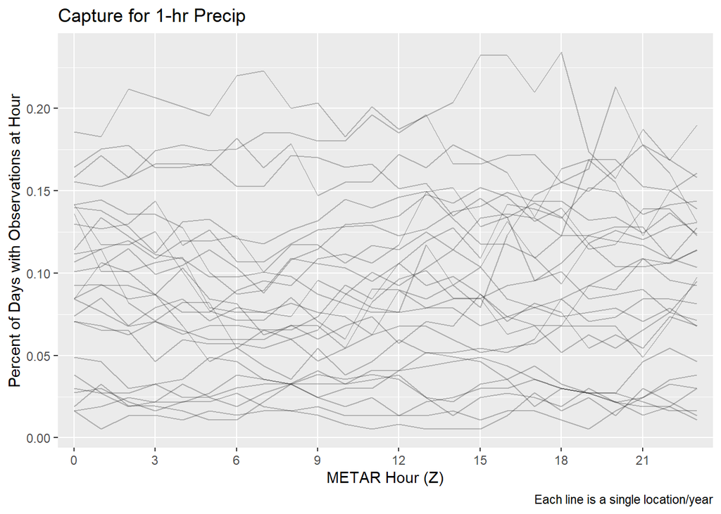

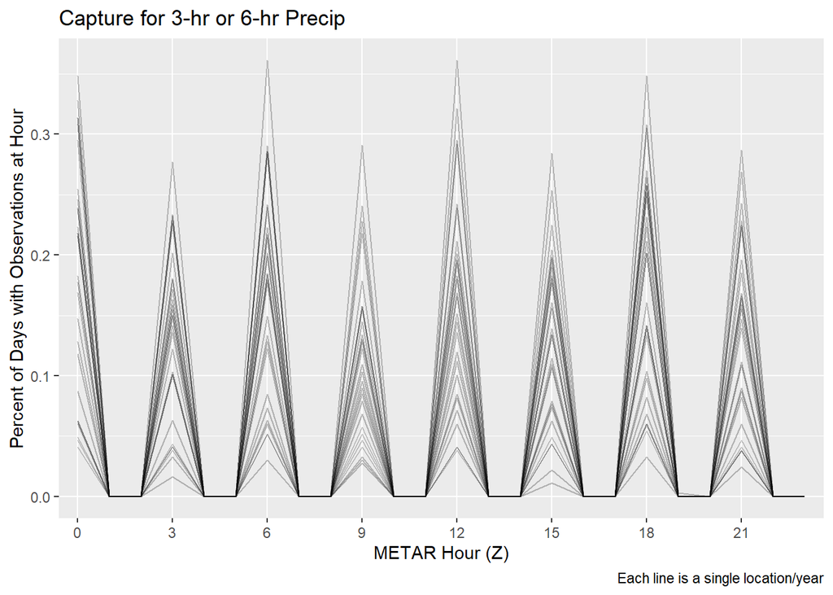

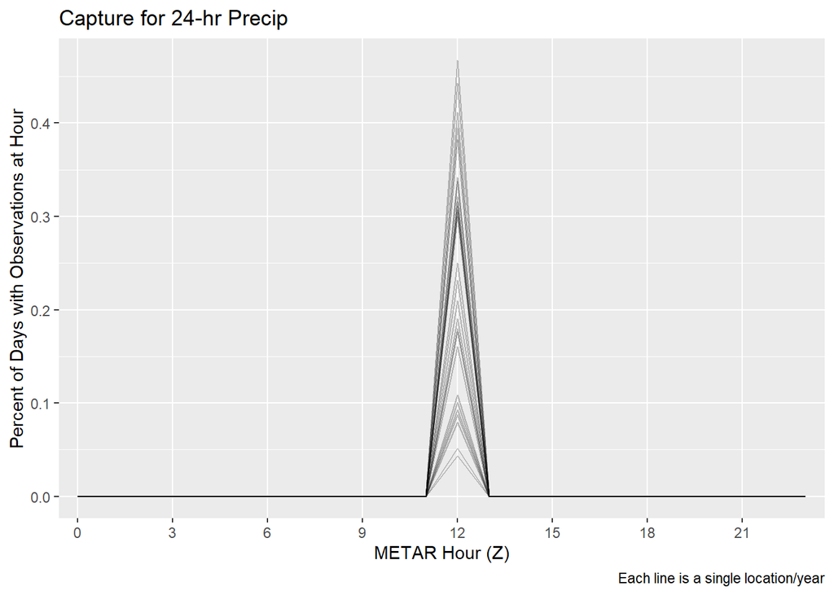

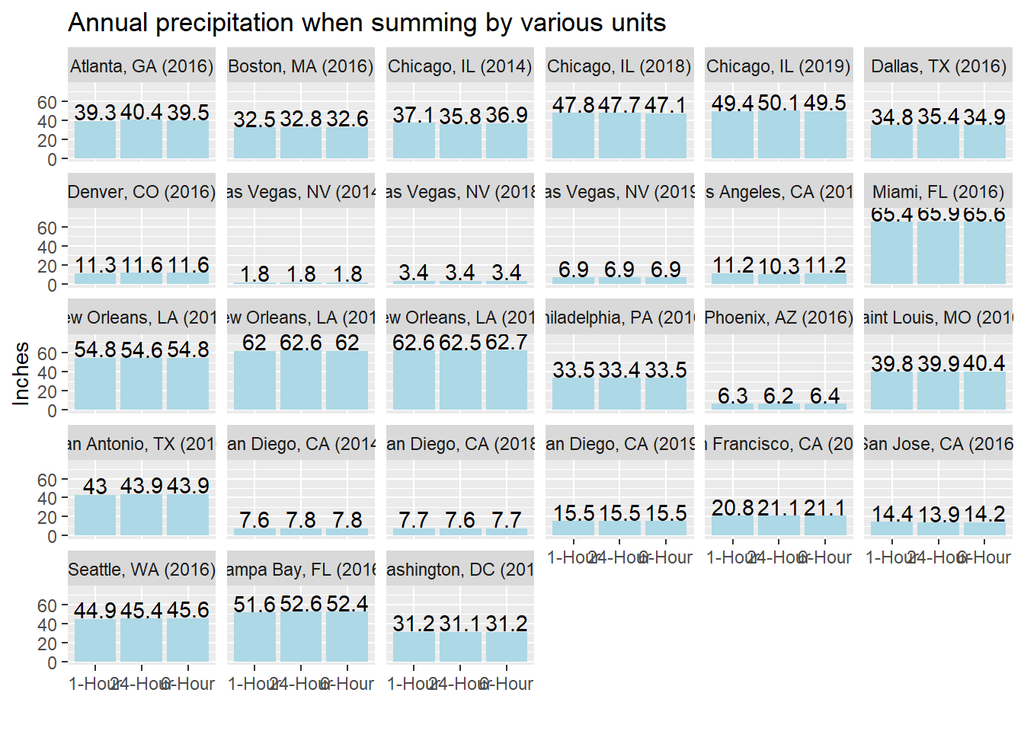

```r
allData <- combineProcessedFiles(integrateNames)
modData <- makePredomDir(allData)
# Show counts by sourceName
modData %>%
    count(source, sourceName)
```

```
## # A tibble: 27 x 3
##    source    sourceName                 n
##    <chr>     <chr>                  <int>
##  1 katl_2016 Atlanta, GA (2016)      8820
##  2 kbos_2016 Boston, MA (2016)       8711
##  3 kdca_2016 Washington, DC (2016)   8757
##  4 kden_2016 Denver, CO (2016)       8820
##  5 kdfw_2016 Dallas, TX (2016)       8820
##  6 klas_2014 Las Vegas, NV (2014)    8787
##  7 klas_2018 Las Vegas, NV (2018)    8794
##  8 klas_2019 Las Vegas, NV (2019)    8804
##  9 klax_2016 Los Angeles, CA (2016)  8822
## 10 kmia_2016 Miami, FL (2016)        8822
## # ... with 17 more rows
```

Functions are then written to create cloud data (level, type, height by source and date-time) and relevant summaries (clouds of up to 12,000 feet, bucketed, with values for minimum height and minimum ceiling):

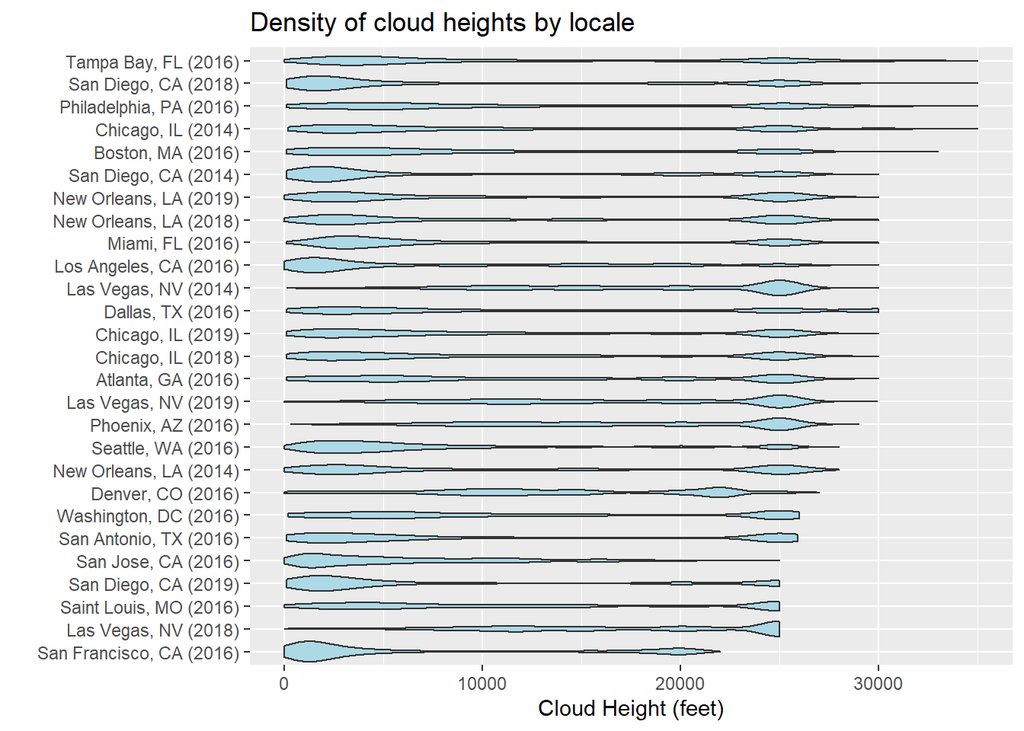

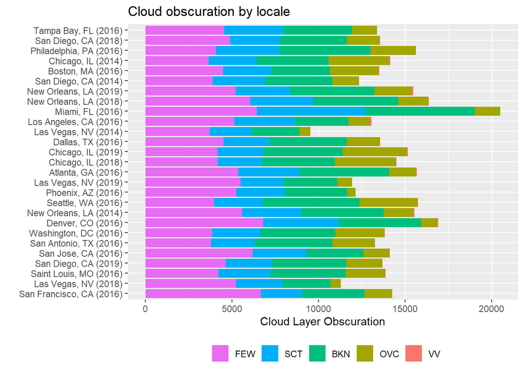

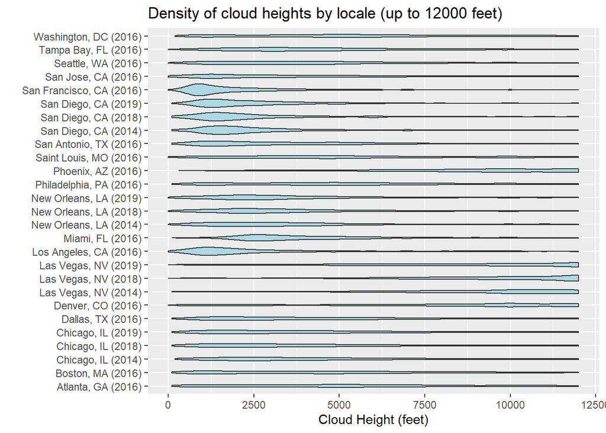

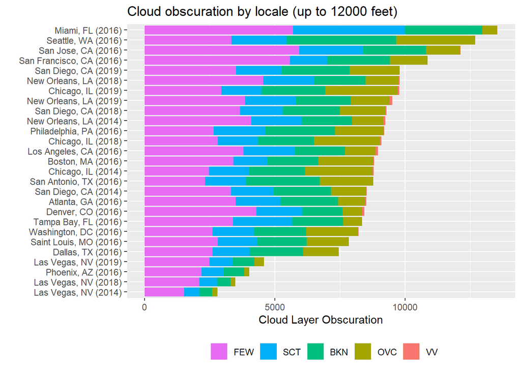

```r
# Create the cloud data object
cData <- createCloudData(modData)
```

```r
# Create the modified cloud data object (add CLR level at -100 if no clouds)
modCData <- cloudsLevel0(cData, maxHeight=12000, byVars=c("source", "sourceName", "dtime")) %>%
    mutate(type=factor(type, levels=c("VV", "OVC", "BKN", "SCT", "FEW", "CLR")))
modCData
```

```
## # A tibble: 469,960 x 6
##    source    sourceName         dtime               level height type
##    <chr>     <chr>              <dttm>              <dbl>  <dbl> <fct>
##  1 katl_2016 Atlanta, GA (2016) 2015-12-31 00:52:00     0   -100 CLR
##  2 katl_2016 Atlanta, GA (2016) 2015-12-31 00:52:00     1    300 FEW
##  3 katl_2016 Atlanta, GA (2016) 2015-12-31 00:52:00     2   4000 BKN
##  4 katl_2016 Atlanta, GA (2016) 2015-12-31 00:52:00     3   9000 OVC
##  5 katl_2016 Atlanta, GA (2016) 2015-12-31 01:52:00     0   -100 CLR
##  6 katl_2016 Atlanta, GA (2016) 2015-12-31 01:52:00     1    300 FEW
##  7 katl_2016 Atlanta, GA (2016) 2015-12-31 01:52:00     2   3800 BKN
##  8 katl_2016 Atlanta, GA (2016) 2015-12-31 01:52:00     3   9000 OVC
##  9 katl_2016 Atlanta, GA (2016) 2015-12-31 02:52:00     0   -100 CLR
## 10 katl_2016 Atlanta, GA (2016) 2015-12-31 02:52:00     1    300 FEW
## # ... with 469,950 more rows
```

```
## # A tibble: 7 x 3
##   ceilingType obscType     n
##   <fct>       <fct>    <int>
## 1 VV          VV         873
## 2 OVC         OVC      24204
## 3 BKN         OVC      14625
## 4 BKN         BKN      31543
## 5 CLR         SCT      26352
## 6 CLR         FEW      55900
## 7 CLR         CLR      83999
## # A tibble: 10 x 3
##    cloudType ceilingType     n
##    <fct>     <fct>       <int>
##  1 VV        VV            873
##  2 OVC       OVC         18044
```

[output cut: 23 more lines]

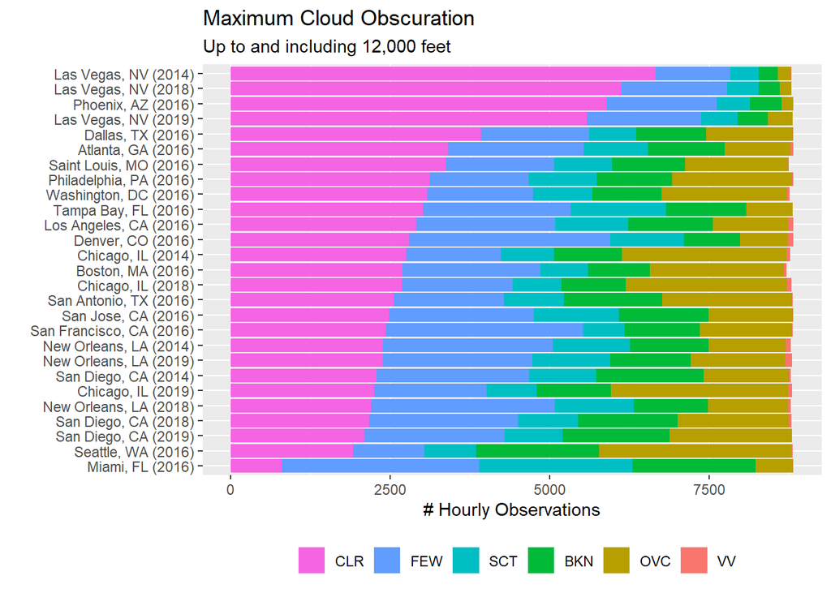

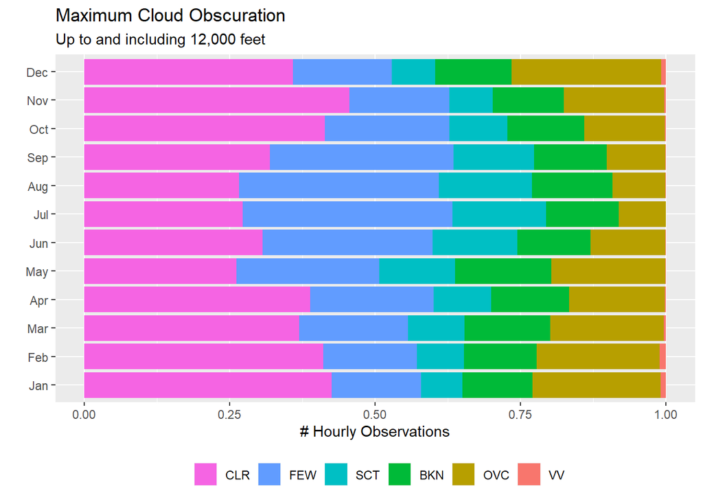

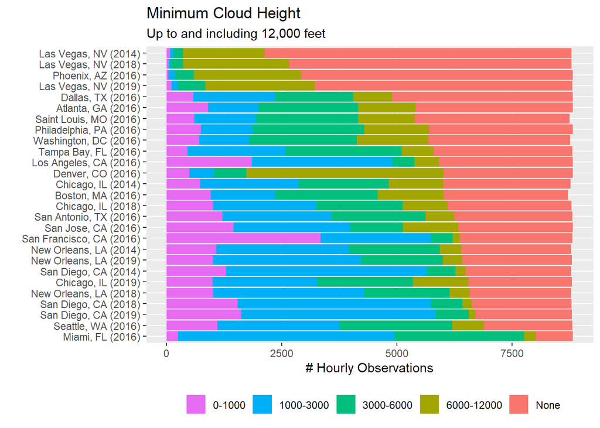

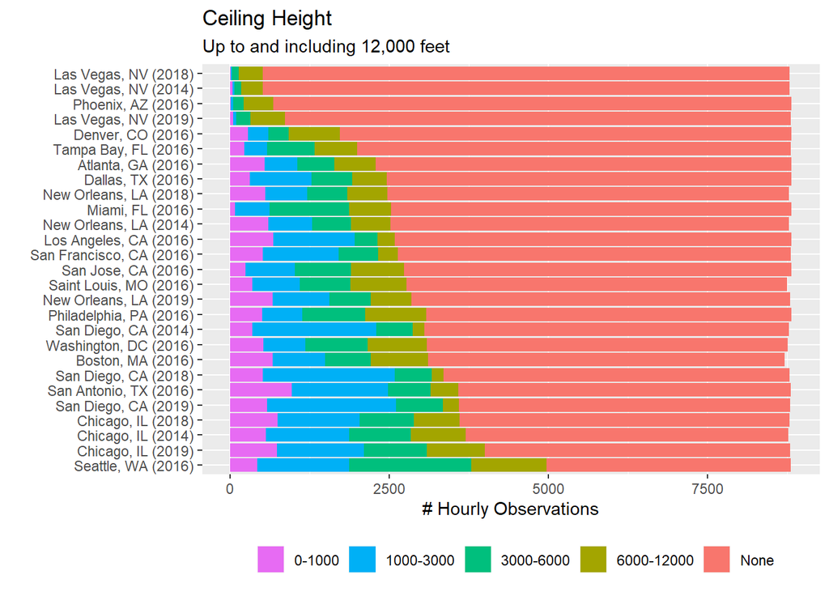

```r
# Get the key clouds data (heights and ceilings)
cloudSummary <- hgtCeilObsc(modCData, byVars=c("source", "sourceName", "dtime")) %>%
    plotAndModifyClouds()
```

A final file containing processed METAR, daily high/low and precipitation, hourly booleans by precipitation type, and cloud height buckets (minimum, minimum ceiling) is created and saved:

```r
# Select the appropriate variables from modData
# Add boolean precipitation by type and hour
# Add summaries for high-low temperature and precipitation amount
# Add summaries for clouds
# Require that the year in the file source match the year of dtime
finalData <- modData %>%
    select(source,
           locale=sourceName,
           dtime,
           origMETAR,
           year,
           monthint,
           month,
           day,
           WindDir,
           WindSpeed,
           WindGust,
           predomDir,
           Visibility,
           Altimeter,
           TempF,
           DewF,
           modSLP,
           starts_with("cType"),
           starts_with("cLevel")
           ) %>%
    addCurrentPrecip() %>%
    addTempPrecipSummaries(precipFile=all_pin, tempFile=all_hilo) %>%
    addCloudSummary(cloudFile=cloudSummary) %>%
    enforceYearCheck()
```

```
##
## Duplicated records occur during:
## # A tibble: 8 x 3
##   station date           n
##   <chr>   <date>     <int>
## 1 klas    2018-12-31    24
## 2 klas    2019-01-01    24
## 3 kmsy    2018-12-31    24
## 4 kmsy    2019-01-01    23
## 5 kord    2018-12-31    24
## 6 kord    2019-01-01    24
## 7 ksan    2018-12-31    24
## 8 ksan    2019-01-01    24
##
## Enforcing year restriction reduces data rows from: 237496 to: 236201
```

```r
# Report summary of the final file, and save as RDS
summary(finalData)
```

```
##     source             locale              dtime
##  Length:236201      Length:236201      Min.   :2014-01-01 00:51:00
##  Class :character   Class :character   1st Qu.:2016-03-08 03:53:00
##  Mode  :character   Mode  :character   Median :2016-08-19 23:52:00
##                                        Mean   :2016-12-11 11:49:11
##                                        3rd Qu.:2018-04-24 23:53:00
##                                        Max.   :2019-12-31 23:56:00
##
##   origMETAR              year         monthint          month
##  Length:236201      Min.   :2014   Min.   : 1.000   Mar    : 20053
##  Class :character   1st Qu.:2016   1st Qu.: 4.000   Dec    : 20050
##  Mode  :character   Median :2016   Median : 7.000   Aug    : 20043
##                     Mean   :2016   Mean   : 6.518   Oct    : 20041
##                     3rd Qu.:2018   3rd Qu.:10.000   Jan    : 20040
##                     Max.   :2019   Max.   :12.000   May    : 20025
##                                                     (Other):115949
##       day          WindDir            WindSpeed         WindGust
##  Min.   : 1.00   Length:236201      Min.   : 0.000   Min.   :12.00
##  1st Qu.: 8.00   Class :character   1st Qu.: 4.000   1st Qu.:18.00
##  Median :16.00   Mode  :character   Median : 7.000   Median :21.00
##  Mean   :15.75                      Mean   : 7.063   Mean   :22.01
##  3rd Qu.:23.00                      3rd Qu.:10.000   3rd Qu.:25.00
##  Max.   :31.00                      Max.   :43.000   Max.   :57.00
##                                     NA's   :623      NA's   :211336
##    predomDir       Visibility       Altimeter         TempF
##  S      :37774   Min.   : 0.000   Min.   :29.06   Min.   :-23.08
##  W      :31739   1st Qu.:10.000   1st Qu.:29.91   1st Qu.: 53.96
##  SW     :26252   Median :10.000   Median :30.01   Median : 64.94
##  000    :25810   Mean   : 9.521   Mean   :30.02   Mean   : 63.94
##  NW     :25286   3rd Qu.:10.000   3rd Qu.:30.12   3rd Qu.: 75.92
##  E      :22262   Max.   :10.000   Max.   :30.88   Max.   :395.60
##  (Other):67078   NA's   :623      NA's   :623     NA's   :623
##       DewF            modSLP          cType1             cType2
##  Min.   :-32.08   Min.   : 984.3   Length:236201      Length:236201
##  1st Qu.: 33.98   1st Qu.:1012.4   Class :character   Class :character
##  Median : 50.00   Median :1016.0   Mode  :character   Mode  :character
##  Mean   : 47.35   Mean   :1016.1
##  3rd Qu.: 60.98   3rd Qu.:1019.8
##  Max.   :210.92   Max.   :1047.4
##  NA's   :623      NA's   :623
```

[output cut: 33 more lines]

```
##  Min.   :-10.0    Min.   :-78.00   Min.   : -100   VV :  863   Min.   : -100
##  1st Qu.: 63.0    1st Qu.: 46.00   1st Qu.: -100   OVC:17872   1st Qu.: -100
##  Median : 74.0    Median : 57.00   Median : 1400   BKN:22774   Median : -100
##  Mean   : 73.1    Mean   : 55.48   Mean   : 2479   SCT:27604   Mean   : 1153
##  3rd Qu.: 86.0    3rd Qu.: 68.00   3rd Qu.: 3900   FEW:83495   3rd Qu.: 1100
##  Max.   :118.0    Max.   : 93.00   Max.   :12000   CLR:83593   Max.   :12000
##  NA's   :226382   NA's   :226382
##  ceilingType
##  VV :   863
##  OVC: 23985
##  BKN: 45867
##  SCT:     0
##  FEW:     0
##  CLR:165486
##
```

```r
saveRDS(finalData, paste0(filePath, metarFileName))
```

The precipitation data is then integrated and saved:

```r
# Integrate the rain, snow, and thunder lists
allPrecipList <- list(rain=rain_List,
                      snow=snow_List,
                      thunder=thunder_List
                      )

# Provide a structure summary, and save as RDS
str(allPrecipList, max.level = 2)
```

```
## List of 3
##  $ rain   :List of 2
##   ..$ precipList  :List of 27
##   ..$ precipLength:Classes 'tbl_df', 'tbl' and 'data.frame': 324 obs. of  5 variables:
##  $ snow   :List of 2
##   ..$ precipList  :List of 27
##   ..$ precipLength:Classes 'tbl_df', 'tbl' and 'data.frame': 324 obs. of  5 variables:
##  $ thunder:List of 2
##   ..$ precipList  :List of 27
##   ..$ precipLength:Classes 'tbl_df', 'tbl' and 'data.frame': 324 obs. of  5 variables:
```

```r
saveRDS(allPrecipList, paste0(filePath, precipFileName))
```

The clouds data are then integrated and saved:

```r
# Run the function to get the filtered clouds data, then save as RDS
modCSaveData <- checkAndFilterClouds(cloudFile=modCData, mainFile=finalData)
```

```
## # A tibble: 0 x 2
## # ... with 2 variables: source <chr>, dtime <dttm>
##       source 2015-12-31 2017-01-01 2013-12-31 2015-01-01 2017-12-31 2019-01-01
## 1  katl_2016         24         24          0          0          0          0
## 2  kbos_2016         24         24          0          0          0          0
## 3  kdca_2016         24         24          0          0          0          0
## 4  kden_2016         24         24          0          0          0          0
## 5  kdfw_2016         24         24          0          0          0          0
## 6  klas_2014          0          0         24         24          0          0
## 7  klas_2018          0          0          0          0         24         24
## 8  klas_2019          0          0          0          0          0          0
## 9  klax_2016         24         24          0          0          0          0
## 10 kmia_2016         24         24          0          0          0          0
## 11 kmsy_2014          0          0         24         24          0          0
## 12 kmsy_2018          0          0          0          0         24         23
```

[output cut: 43 more lines]

```r
saveRDS(modCSaveData, paste0(filePath, cloudFileName))
```